# 2026년 8월 월간 기업·산업 분석

AI 메모리 슈퍼사이클 — 삼성전자·SK하이닉스와 DRAM/HBM/NAND 병목

저자

Alpha Hunter × Chimera AI

공개

2026년 8월 23일

**경고연구 목적 고지**

이 글은 Alpha Hunter의 **월간 기업분석·산업분석 저널**이다. 공개 공시, 기업 IR, 공식 실적 발표, 시장조사기관 공개자료를 바탕으로 작성한 정보·연구 목적의 리서치이며, 특정 증권의 매수·매도·보유를 권유하는 투자자문이 아니다. 모든 투자 판단은 독자 본인의 책임이다.

# 1 월간 결론: 가격보다 먼저 수급 병목을 읽어야 한다

2026년 8월의 핵심 산업 이벤트는 **AI 수요가 HBM만이 아니라 범용 DRAM·eSSD·NAND까지 끌어올린 점**이다. 삼성전자와 SK하이닉스 모두 2026년 2분기에 기록적인 수익성을 발표했다. 그러나 이번 월간호의 결론은 “무조건 반도체를 사라”가 아니다. 더 중요한 질문은 세 가지다.

1. **누가 병목을 가격으로 전가할 수 있는가.**  
   Omdia는 2026년 반도체 매출 전망을 전년 대비 `94.1%` 성장으로 상향했고, 메모리 IC가 전체 반도체 매출의 절반 이상을 차지할 것으로 봤다. 병목은 HBM, 첨단 패키징, 선단 노드에 집중된다.
2. **HBM 프리미엄만 보던 관점은 부족해졌다.**  
   Counterpoint는 2026년 2분기 DRAM 점유율에서 삼성전자가 `39%`로 1위를 회복했고 SK하이닉스는 `26%`, Micron은 `25%`로 좁혀졌다고 밝혔다. HBM 가격만이 아니라 범용 DRAM 가격 상승과 LTA 구조가 실적 차이를 만들었다.
3. **기업분석의 초점은 ‘AI 노출도’에서 ‘계약·제품믹스·CAPEX discipline’으로 이동한다.**  
   SK하이닉스는 약 10개 고객과 장기공급계약을 체결했다고 밝혔고, 삼성전자는 HBM4 확대와 HBM4E 샘플 출하, DDR5·SOCAMM2·eSSD 확대를 제시했다. 같은 AI 메모리라도 계약 시점과 가격 조항에 따라 이익 민감도가 다르다.

| 월간 체크포인트 | 이번 달 확인 | Alpha Hunter 해석 |
| --- | --- | --- |
| 삼성전자 Q2 연결 매출/영업이익 | 171.5조 / 89.5조 원 | DS가 사실상 전사 이익을 견인 |
| 삼성전자 DS 매출/영업이익 | 127.5조 / 89.2조 원 | 메모리 중심 영업레버리지 극대화 |
| SK하이닉스 Q2 매출/영업이익 | 79.3187조 / 60.5426조 원 | OPM 76%, HBM·AI 서버 DRAM·eSSD 믹스 |
| Omdia 2026 반도체 전망 | +94.1% YoY | 메모리·패키징 병목이 산업 레짐을 지배 |
| Counterpoint Q2 DRAM 점유율 | 삼성 39%, SK하이닉스 26%, Micron 25% | HBM 단일 승부에서 범용 DRAM 포함 총력전으로 전환 |
| TrendForce Q2 NAND 상위 5사 매출 | 688.7억 달러, +77% QoQ | eSSD 수요와 ASP 상승이 NAND까지 확산 |

# 2 기업분석 1 — 삼성전자: DS가 전사를 압도한 분기

삼성전자는 2026년 7월 30일 2분기 실적을 발표했다. 연결 기준 매출은 `171.5조 원`, 영업이익은 `89.5조 원`이다. 전분기 대비 매출은 `37.6조 원`, 영업이익은 `32.3조 원` 늘었다. 사업부별로 보면 DS 부문 매출은 `127.5조 원`, 영업이익은 `89.2조 원`으로 전사 영업이익 대부분을 차지했다. DX 부문은 매출 `48조 원`, 영업손실 `0.8조 원`, 디스플레이는 매출 `7.5조 원`, 영업이익 `0.7조 원`, 하만은 매출 `4.6조 원`, 영업이익 `0.4조 원`이었다.

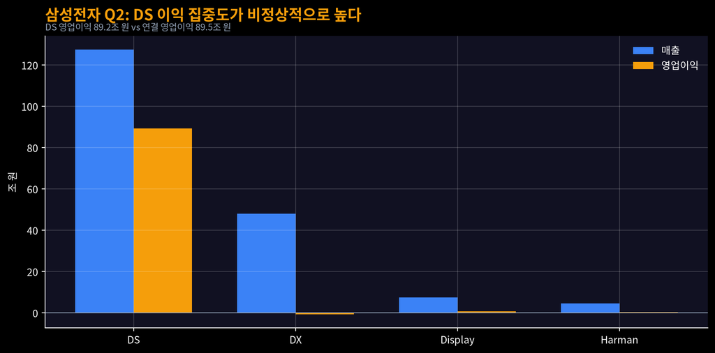

그림 1: 그림 1. 삼성전자 2026년 2분기 사업부별 매출과 영업이익. 출처: Samsung Newsroom Korea, 2026-07-30.

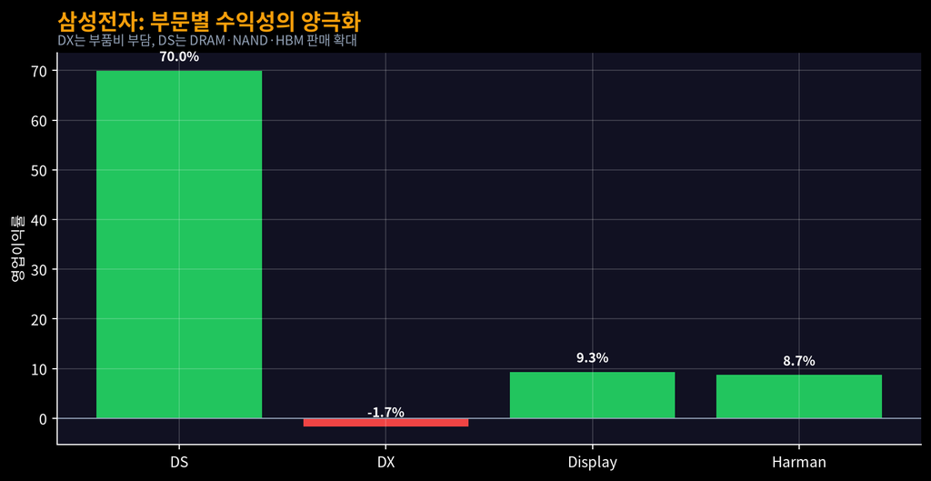

그림 2: 그림 2. 삼성전자 사업부별 영업이익률. DS는 메모리 가격과 제품믹스가 동시에 작동했다.

삼성전자의 월간 분석 포인트는 두 가지다.

- **메모리의 범위가 넓어졌다.** 회사는 하반기 전략으로 HBM4·HBM4E뿐 아니라 DDR5, SOCAMM2, eSSD 판매 확대를 제시했다. AI가 GPU 가속기만의 문제가 아니라 서버 CPU, 추론 서비스, 스토리지까지 확산된다는 뜻이다.
- **DS 외 사업부의 비용 압박은 숨은 리스크다.** DX의 손실은 메모리 가격 상승이 고객사·완제품 사업에는 비용이 된다는 점을 보여준다. 같은 그룹 안에서도 메모리 공급자는 수혜, 세트 사업은 압박을 동시에 받는다.

# 3 기업분석 2 — SK하이닉스: 최고 수익성, 그러나 점유율·계약가격의 질문

SK하이닉스는 2026년 7월 29일 2분기 실적을 발표했다. 매출은 `79.3187조 원`, 영업이익은 `60.5426조 원`, 순이익은 `93.9226조 원`이었다. 영업이익률은 `76%`다. 전년 동기 매출 `22.232조 원`, 영업이익 `9.2129조 원` 대비 각각 `257%`, `557%` 증가했다. 전분기 매출 `52.5763조 원`, 영업이익 `37.6103조 원`보다도 크게 늘었다.

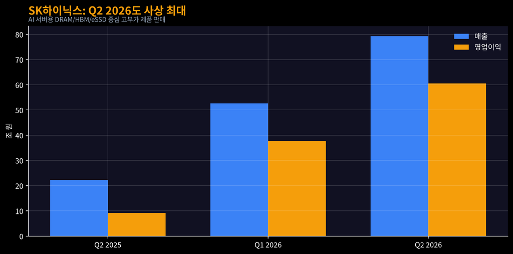

그림 3: 그림 3. SK하이닉스 분기 실적 비교. 출처: SK hynix Newsroom, 2026-07-29.

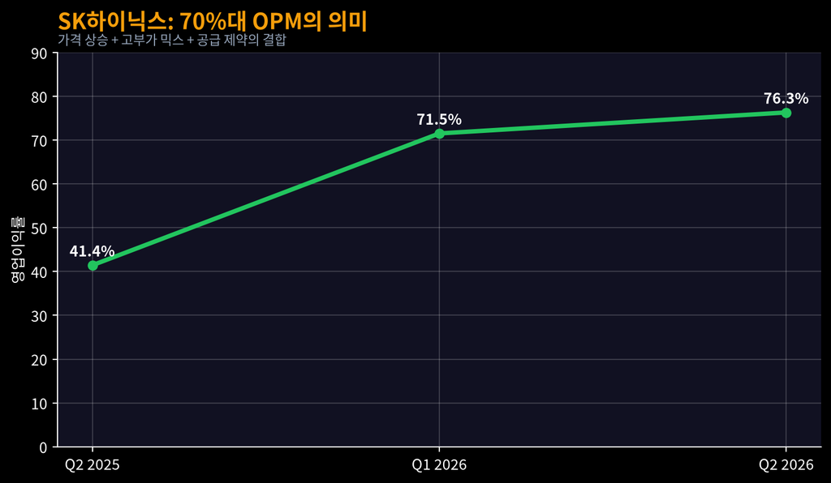

그림 4: 그림 4. SK하이닉스 영업이익률 추이. 공식 발표 수치로 계산.

긍정적 요소는 명확하다. 회사는 현금 및 현금성자산이 전분기 대비 `33.6조 원` 증가해 `88조 원`이 되었고, 총차입금은 `18.6조 원`으로 감소했다고 밝혔다. 동시에 약 10개 핵심 고객과 장기공급계약을 맺었다고 설명했다. 이는 다운사이클에서의 실적 방어력을 높일 수 있다.

다만 Counterpoint의 Q2 DRAM 점유율 분석은 중요한 질문을 남긴다. SK하이닉스는 실적이 사상 최대였지만 Q2 DRAM 매출 점유율은 `26%`로, 삼성 `39%`, Micron `25%`와 격차가 좁아졌다. HBM 비중이 높고 LTA를 일찍 체결한 구조는 수요 안정성에는 장점이지만, 가격 급등 국면에서는 상단을 일부 제한할 수 있다.

# 4 산업분석 — HBM 단일 병목에서 메모리 전반 병목으로

Omdia는 2026년 반도체 매출 전망을 전년 대비 `94.1%` 성장으로 상향했다. 핵심 문장은 “메모리 IC가 2026년 전체 반도체 매출의 50% 이상을 차지할 전망”이라는 대목이다. HBM, 첨단 패키징, 선단 노드 병목은 적어도 2027년까지 이어질 것으로 제시됐다.

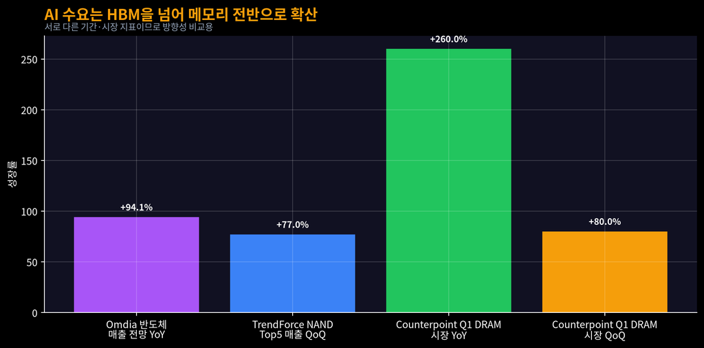

그림 5: 그림 5. 2026년 공개 시장조사 핵심 수치. Omdia·TrendForce·Counterpoint 공개자료 기반.

Counterpoint의 Q2 2026 DRAM 점유율은 이번 월간호의 산업 판도를 가장 압축적으로 보여준다.

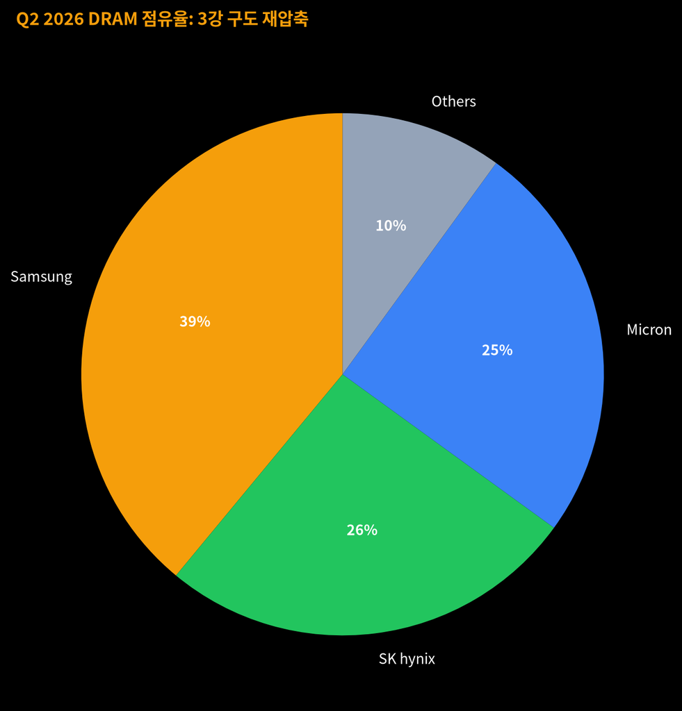

그림 6: 그림 6. 2026년 2분기 DRAM 매출 점유율. 출처: Counterpoint Research Global Memory Tracker 공개요약.

TrendForce는 2026년 8월 18일, Q2 NAND 상위 5개 상장 브랜드 매출이 전분기 대비 `77%` 증가해 `688.7억 달러`에 도달했다고 밝혔다. 삼성 NAND 매출은 `230.6억 달러`, SK하이닉스 그룹은 `142.7억 달러`, Micron은 `118.5억 달러`, Kioxia는 `107.2억 달러`, SanDisk는 `89.7억 달러`다. AI 서버용 eSSD 수요가 NAND 가격 협상을 밀어 올린 것이다.

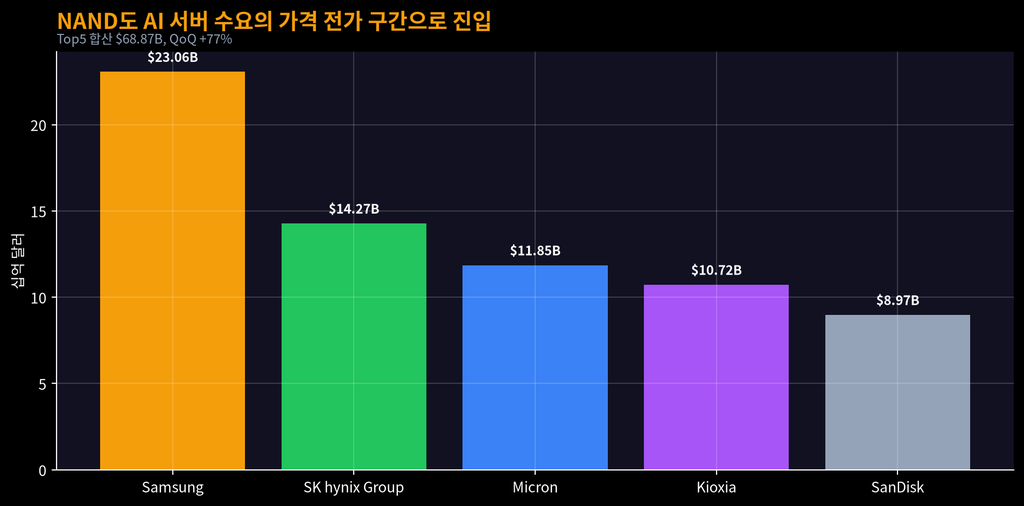

그림 7: 그림 7. Q2 2026 NAND 상위 5개 브랜드 매출. 출처: TrendForce, 2026-08-18.

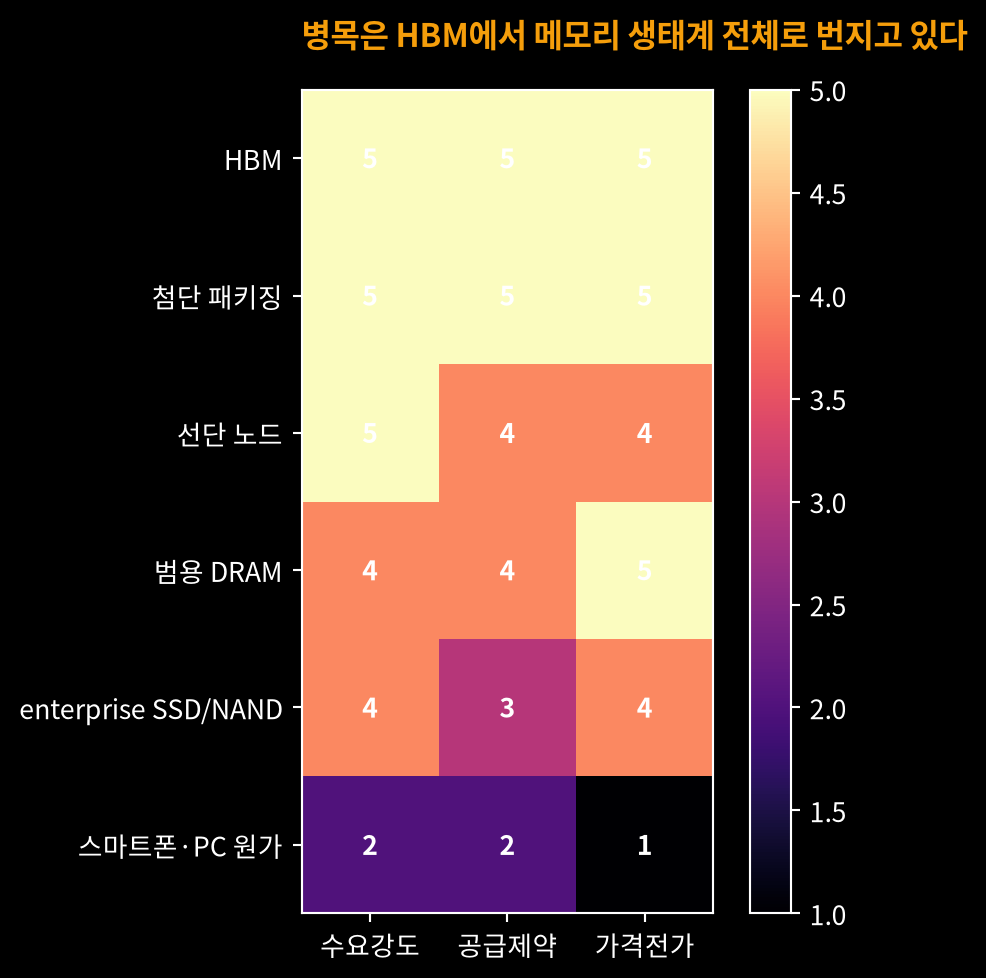

그림 8: 그림 8. AI 메모리 병목 지도. 공개자료를 정성 점수화한 Alpha Hunter 프레임.

# 5 증권사·리서치 관점에서 보는 논쟁점

공개 기사와 기업 발표에 나타난 증권사·시장조사기관 관점은 대체로 “수요는 강하지만 가격과 CAPEX의 지속성이 핵심”으로 모인다. 연합인포맥스가 집계한 6월 전망에서는 삼성전자와 SK하이닉스 Q2 합산 영업이익이 150조 원을 넘을 것으로 예상됐고, 실제 발표도 그 방향을 확인했다. 다만 실적 발표 후 시장 변동성은 컸다. 이는 실적 숫자 자체보다 **향후 AI 투자수익률, 과잉투자, 메모리 가격 지속성**을 시장이 재평가하고 있음을 뜻한다.

Alpha Hunter의 이번 달 해석은 다음과 같다.

- **삼성전자:** 범용 DRAM·NAND 가격 상승과 대형 생산능력의 조합이 실적 레버리지를 키웠다. HBM4E와 파운드리/HBM 베이스 다이는 추가 옵션이다. 다만 세트 사업 비용 압박과 CAPEX 확대 국면의 공급 과잉 위험을 같이 봐야 한다.
- **SK하이닉스:** HBM 선도력과 LTA는 장기 안정성의 핵심이다. 하지만 Q2처럼 범용 DRAM 가격이 급등하는 구간에서는 경쟁사의 일반 DRAM 공급능력과 계약가격 구조가 상대 수익률을 좌우할 수 있다.
- **Micron 및 장비·패키징 체인:** DRAM 점유율 25%, NAND 매출 +99.2% QoQ라는 공개 수치는 미국 메모리 업체도 가격 전가 구간에 들어왔음을 보여준다. 한국 밸류체인은 HBM 소재·검사·패키징·eSSD 밸류체인을 분리해 봐야 한다.

# 6 9월 모니터링 리스트

1. **DART 반기보고서 세부 주석:** 삼성전자와 SK하이닉스 모두 2026년 반기보고서가 2026년 8월 14일 접수된 것으로 확인된다. 다음 점검은 재고, 유형자산, 고객집중, CAPEX, 약정사항이다.
2. **HBM4·HBM4E 실제 출하와 가격:** HBM4 전환은 기술 뉴스가 아니라 평균판매가격과 수율의 문제다.
3. **범용 DRAM 계약가격:** Q3 가격 인상 폭이 유지되면 삼성전자 레버리지가 더 커질 수 있다. 반대로 HBM 가격 반등이 빨라지면 SK하이닉스 상대 매력이 회복될 수 있다.
4. **NAND/eSSD:** TrendForce가 확인한 Q2 NAND ASP 상승이 Q3에도 이어지는지 확인한다.
5. **세트 업체 마진:** 스마트폰·PC·가전의 BOM 부담이 가격 인상으로 전가되는지, 수요 파괴로 나타나는지 확인해야 한다.

# 7 출처와 재현 기준

- [삼성전자 2026년 2분기 실적 발표, Samsung Newsroom Korea, 2026-07-30](https://news.samsung.com/kr/%EC%82%BC%EC%84%B1%EC%A0%84%EC%9E%90-2026%EB%85%84-2%EB%B6%84%EA%B8%B0-%EC%8B%A4%EC%A0%81-%EB%B0%9C%ED%91%9C)
- [SK hynix Announces 2Q26 Financial Results, SK hynix Newsroom, 2026-07-29](https://news.skhynix.com/en/q2-2026-business-results/)
- [Omdia: AI demand drives 94.1% surge in semiconductor forecast for 2026, 2026-07-30](https://omdia.tech.informa.com/pr/2026/july/ai-demand-drives-94-point-1-percent-surge-in-semiconductor-forecast-for-2026)
- [Counterpoint Research: AI Demand Reshapes DRAM Rankings in Q2 2026, 2026-08-03](https://counterpointresearch.com/en/insights/ai-demand-reshapes-dram-rankings-in-q2-2026)
- [TrendForce: Combined Revenue of Top Five NAND Flash Brands Rises 77% QoQ in 2Q26, 2026-08-18](https://www.trendforce.com/presscenter/news/20260818-13186.html)
- [삼성전자 공시정보: 반기보고서 2026.06 접수 2026-08-14 및 2026-08-21 주요 공시 목록](https://ir.gsifn.io/sample/ir_notices.html)
- [금융감독원 DART: SK하이닉스 정기공시 항목별 검색 — 반기보고서 사업연도 2026](https://dart.fss.or.kr/navi/searchNavi.do?naviCode=C001&naviCrpCik=00164779&naviCrpNm=SK%ED%95%98%EC%9D%B4%EB%8B%89%EC%8A%A4)

수치는 위 공개자료에 명시된 값을 QMD 내부에 고정해 재현했다. 실시간 주가, 계좌, 비공개 리포트 전문, 유료 데이터베이스 원문은 사용하지 않았다.